# A study on Australia Tourism Data

1. Data Visualizations
2. Time Series Analysis
3. Regression Models

##### by Sinan DEMIRHAN

```r
library(tsibble)
library(plyr)
library(dplyr)
library(leaflet)
library(ggplot2)
require(stats)
library(basicTrendline)
library(fpp2)
library(TSPred)
library(lubridate)
library(fable)
library(forecast)
library(tidyverse)
library(caret)
library(class)
require(gridExtra)
library(hrbrthemes)
library(wordcloud2)
library(dummies)
library(tree)
library(caret)
library(rpart)
library(rpart.plot)
```

# Data Visualizations

```r
df <-tourism
summary(df)
```

```
##     Quarter           Region             State
##  Min.   :1998 Q1   Length:24320       Length:24320
##  1st Qu.:2002 Q4   Class :character   Class :character
##  Median :2007 Q4   Mode  :character   Mode  :character
##  Mean   :2007 Q4
##  3rd Qu.:2012 Q4
##  Max.   :2017 Q4
##    Purpose              Trips
##  Length:24320       Min.   :  0.000
##  Class :character   1st Qu.:  7.224
##  Mode  :character   Median : 28.134
##                     Mean   : 70.896
##                     3rd Qu.: 78.154
##                     Max.   :985.278
```

```r
length(df$Quarter)  #24320
```

```
## [1] 24320
```

```r
lengths(tourism %>% filter(Region == "Adelaide")) #So 24320/320 =76
```

```
## Quarter  Region   State Purpose   Trips
##     320     320     320     320     320
```

```r
unique(df$Region) #76 Region
```

```
##  [1] "Adelaide"                        "Adelaide Hills"
##  [3] "Alice Springs"                   "Australia's Coral Coast"
##  [5] "Australia's Golden Outback"      "Australia's North West"
##  [7] "Australia's South West"          "Ballarat"
##  [9] "Barkly"                          "Barossa"
## [11] "Bendigo Loddon"                  "Blue Mountains"
## [13] "Brisbane"                        "Bundaberg"
## [15] "Canberra"                        "Capital Country"
## [17] "Central Coast"                   "Central Highlands"
## [19] "Central Murray"                  "Central NSW"
## [21] "Central Queensland"              "Clare Valley"
## [23] "Darling Downs"                   "Darwin"
## [25] "East Coast"                      "Experience Perth"
## [27] "Eyre Peninsula"                  "Fleurieu Peninsula"
## [29] "Flinders Ranges and Outback"     "Fraser Coast"
```

[output cut: 23 more lines]

```r
unique(df$State)
```

```
## [1] "South Australia"    "Northern Territory" "Western Australia"
## [4] "Victoria"           "New South Wales"    "Queensland"
## [7] "ACT"                "Tasmania"
```

```r
unique(df$Purpose)
```

```
## [1] "Business" "Holiday"  "Other"    "Visiting"
```

```r
#dividing date column into quarters and years
df$Years <- sapply(strsplit(as.character(df$Quarter), " "), "[", 1)
df$Quarters<-sapply(strsplit(as.character(df$Quarter)," "),"[",2)
```

```r
glimpse(df)
```

```
## Observations: 24,320
## Variables: 7
## Key: Region, State, Purpose [304]
## $ Quarter  <qtr> 1998 Q1, 1998 Q2, 1998 Q3, 1998 Q4, 1999 Q1, 1999 Q2,...
## $ Region   <chr> "Adelaide", "Adelaide", "Adelaide", "Adelaide", "Adel...
## $ State    <chr> "South Australia", "South Australia", "South Australi...
## $ Purpose  <chr> "Business", "Business", "Business", "Business", "Busi...
## $ Trips    <dbl> 135.0777, 109.9873, 166.0347, 127.1605, 137.4485, 199...
## $ Years    <chr> "1998", "1998", "1998", "1998", "1999", "1999", "1999...
## $ Quarters <chr> "Q1", "Q2", "Q3", "Q4", "Q1", "Q2", "Q3", "Q4", "Q1",...
```

```r
region_data<-tourism %>%
  group_by(Region,State) %>%
  summarise(Total_Trips = sum(Trips))

region_data<-aggregate(df$Trips, by=list(Region=df$Region,States=df$State), FUN=sum)
region_data<-region_data %>%
  rename(
    Total_Trips = x
  )
region_data<-region_data %>% arrange(desc(Total_Trips))

wordcloud2(select(region_data,c(Region,Total_Trips)), size=0.5, color='random-dark')
```

[interactive chart not shown]

##### region_data has the Region column and the total trips which indicates total trips done between years 1998 and 2017 in that region.

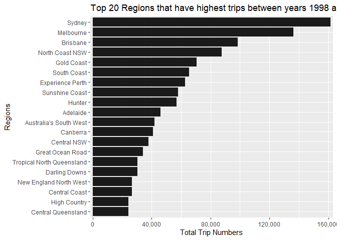

```r
ggplot(region_data[1:20,], aes(y = Total_Trips[1:20], x = reorder(Region, Total_Trips)))+
  geom_col(fill = "grey10") +
  coord_flip()+
  scale_y_comma()+
  labs(title = "Top 20 Regions that have highest trips between years 1998 and 2017",
                x = "Regions", y = "Total Trip Numbers")
```

```r
state_data<-aggregate(df$Trips, by=list(States=df$State), FUN=sum)
state_data<-state_data %>%
  rename(
    Total_Trips = x
  )
state_data<-state_data %>% arrange(desc(Total_Trips))
state_data
```

```
##               States Total_Trips
## 1    New South Wales   557367.43
## 2           Victoria   390462.91
## 3         Queensland   386642.91
## 4  Western Australia   147819.65
## 5    South Australia   118151.35
## 6           Tasmania    54137.09
## 7                ACT    41006.59
## 8 Northern Territory    28613.68
```

##### state_data has also the State column and the total trips which indicates total trips done between years 1998 and 2017 in that state.

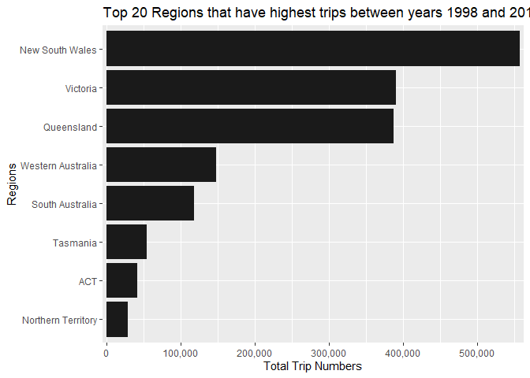

```r
ggplot(state_data, aes(y = Total_Trips, x = reorder(States, Total_Trips)))+
  geom_col(fill = "grey10") +
  coord_flip()+
  scale_y_comma()+
  labs(title = "Top 20 Regions that have highest trips between years 1998 and 2017",
       x = "Regions", y = "Total Trip Numbers")
```

```r
purpose_data<-array(0,dim = c(76,5))
colnames(purpose_data)<-c("Regions","Business","Holiday","Other","Visiting")
purpose_data<-data.frame(purpose_data)
```

##### Created purpose_data to look at the total trips for each purpose on each Region.

```r
for (i in c(1:76)) {
  re<-region_data$Region[i]
  purposes<-df %>% filter(Region== re)
  purposes<-aggregate(purposes$Trips, by=list(Purpose=purposes$Purpose), FUN=sum)
  purpose_data$Regions[i]<-re
  purpose_data$Business[i]<-purposes$x[1]
  purpose_data$Holiday[i]<-purposes$x[2]
  purpose_data$Other[i]<-purposes$x[3]
  purpose_data$Visiting[i]<-purposes$x[4]
}
a<-purpose_data %>% filter(Business== max(purpose_data$Business))
b<-purpose_data %>% filter(Holiday== max(purpose_data$Holiday))
c<-purpose_data %>% filter(Other== max(purpose_data$Other))
d<-purpose_data %>% filter(Visiting== max(purpose_data$Visiting))

highest_regions<-rbind(a,b,c,d)

for (i in c(1:76)) {
  tot<-sum(purpose_data[i,2:5])
  purpose_data$Business[i]<-(purpose_data$Business[i]/tot)*100
  purpose_data$Holiday[i]<-(purpose_data$Holiday[i]/tot)*100
  purpose_data$Other[i]<-(purpose_data$Other[i]/tot)*100
  purpose_data$Visiting[i]<-(purpose_data$Visiting[i]/tot)*100
}

a<-purpose_data %>% filter(Business== max(purpose_data$Business))
b<-purpose_data %>% filter(Holiday== max(purpose_data$Holiday))
c<-purpose_data %>% filter(Other== max(purpose_data$Other))
d<-purpose_data %>% filter(Visiting== max(purpose_data$Visiting))

highest_regions_with_ratio<-rbind(a,b,c,d)
head(purpose_data,n=10)
```

```
##             Regions  Business  Holiday    Other Visiting
## 1            Sydney 29.802880 27.24274 5.962396 36.99198
## 2         Melbourne 28.081175 29.80279 5.755864 36.36017
## 3          Brisbane 24.766075 28.21309 6.989864 40.03098
## 4   North Coast NSW 10.086402 53.64329 2.806726 33.46358
## 5        Gold Coast 10.081110 60.03542 2.411989 27.47148
## 6       South Coast  7.234795 60.64473 2.418564 29.70191
## 7  Experience Perth 22.114212 32.44205 8.365066 37.07868
## 8    Sunshine Coast  6.549021 60.26825 2.603138 30.57959
## 9            Hunter 13.839907 44.84818 3.591309 37.72061
## 10         Adelaide 27.103554 27.28053 9.857205 35.75871
```

```r
highest_regions_with_ratio
```

```
##                  Regions  Business  Holiday    Other Visiting
## 1 Australia's North West 55.236432 32.68447 1.824719 10.25438
## 2             East Coast  5.060183 82.37321 1.601592 10.96501
## 3               Adelaide 27.103554 27.28053 9.857205 35.75871
## 4                Macedon 12.373742 30.52101 3.288290 53.81695
```

```r
highest_regions
```

```
##           Regions  Business  Holiday    Other Visiting
## 1          Sydney 48163.511 44026.15 9635.643 59781.60
## 2 North Coast NSW  8843.248 47031.73 2460.796 29339.18
## 3          Sydney 48163.511 44026.15 9635.643 59781.60
## 4          Sydney 48163.511 44026.15 9635.643 59781.60
```

```r
a<-array(0,dim = c(4,3))
a<-data.frame(a)
colnames(a)<-c("Region","Purpose","Trips")
purpose_plot=NULL
for(i in c(1:76)){
  for(j in c(2:5)){
    a$Region[j-1]<-purpose_data[i,1]
    a$Purpose[j-1]<-colnames(purpose_data)[j]
    a$Trips[j-1]<-purpose_data[i,j]
  }
  purpose_plot<-rbind(purpose_plot,a)
}
head(purpose_plot,n = 20)
```

```
##             Region  Purpose     Trips
## 1           Sydney Business 29.802880
## 2           Sydney  Holiday 27.242741
## 3           Sydney    Other  5.962396
## 4           Sydney Visiting 36.991983
## 5        Melbourne Business 28.081175
## 6        Melbourne  Holiday 29.802787
## 7        Melbourne    Other  5.755864
## 8        Melbourne Visiting 36.360174
## 9         Brisbane Business 24.766075
## 10        Brisbane  Holiday 28.213086
## 11        Brisbane    Other  6.989864
## 12        Brisbane Visiting 40.030975
## 13 North Coast NSW Business 10.086402
## 14 North Coast NSW  Holiday 53.643290
## 15 North Coast NSW    Other  2.806726
## 16 North Coast NSW Visiting 33.463582
## 17      Gold Coast Business 10.081110
## 18      Gold Coast  Holiday 60.035418
## 19      Gold Coast    Other  2.411989
## 20      Gold Coast Visiting 27.471483
```

##### To plot grouped barplots according to regions and purposes,I constructed a data frame called purpose_plot.

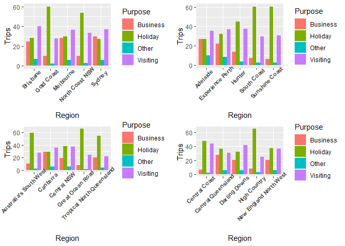

```r
plot1<-ggplot(purpose_plot[1:20,], aes(fill=Purpose, y=Trips, x=Region)) +
  geom_bar(position="dodge", stat="identity")+ theme(axis.text.x = element_text(face = "bold",size = 8, angle = 45,hjust = 0.8))
plot2<-ggplot(purpose_plot[21:40,], aes(fill=Purpose, y=Trips, x=Region)) +
  geom_bar(position="dodge", stat="identity")+ theme(axis.text.x = element_text(face = "bold",size = 8, angle = 45,hjust = 0.8))
plot3<-ggplot(purpose_plot[41:60,], aes(fill=Purpose, y=Trips, x=Region)) +
  geom_bar(position="dodge", stat="identity")+ theme(axis.text.x = element_text(face = "bold",size = 8, angle = 45,hjust = 0.8))
plot4<-ggplot(purpose_plot[61:80,], aes(fill=Purpose, y=Trips, x=Region)) +
  geom_bar(position="dodge", stat="identity")+ theme(axis.text.x = element_text(face = "bold",size = 8, angle = 45,hjust = 0.8))

grid.arrange(plot1, plot2,plot3,plot4,nrow=2 ,ncol=2)
```

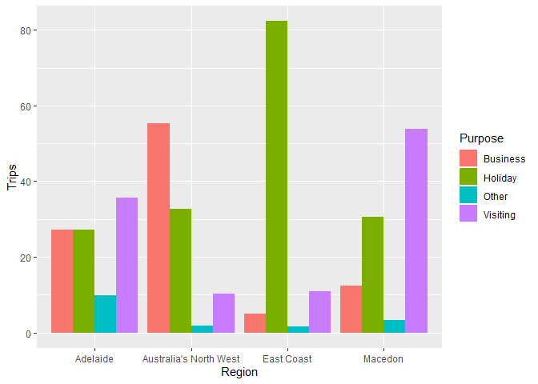

```r
high_regions=NULL
for(i in c(1:4)){
  for(j in c(2:5)){
    a$Region[j-1]<-highest_regions_with_ratio[i,1]
    a$Purpose[j-1]<-colnames(highest_regions_with_ratio)[j]
    a$Trips[j-1]<-highest_regions_with_ratio[i,j]
  }
  high_regions<-rbind(high_regions,a)
}

ggplot(high_regions, aes(fill=Purpose, y=Trips, x=Region)) +
  geom_bar(position="dodge", stat="identity")
```

##### This four region has the highest trip ratios according to four different purposes.

```r
stf<-region_data %>% arrange(desc(States))
total<-sum(stf$Total_Trips)
for(i in c(1:nrow(stf))){
  stf$Total_Trips[i]<-(stf$Total_Trips[i]/total)*1000
}
stf$States<-as.factor(stf$States)
empty_bar <- 1
to_add <- data.frame( matrix(NA, empty_bar*nlevels(stf$States), ncol(stf)) )
colnames(to_add) <- colnames(stf)
to_add$States <- rep(levels(stf$States), each=empty_bar)
stf <- rbind(stf, to_add)
stf <- stf %>% arrange(States)
stf$id <- seq(1, nrow(stf))
labels <- stf
number_of_bar <- nrow(labels)
angle <- 90 - 360 * (labels$id-0.5) /number_of_bar
labels$hjust <- ifelse( angle < -90, 1, 0)
labels$angle <- ifelse(angle < -90, angle+180, angle)
```

##### In order to construct Circular barplot with Regions and States,made some implementations

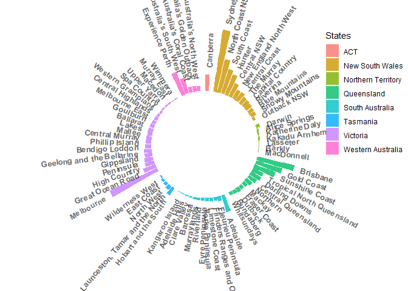

```r
p <- ggplot(stf, aes(x=as.factor(id), y=Total_Trips, fill=States)) +
  geom_bar(stat="identity", alpha=0.8) +
  ylim(-80,120) +
  theme_minimal() +
  theme(
    legend.position = "none",
    axis.text = element_blank(),
    axis.title = element_blank(),
    panel.grid = element_blank(),
    plot.margin = unit(rep(-1,8), "cm")
  ) +
  coord_polar() +
  geom_text(data=labels, aes(x=id, y=Total_Trips+10, label=Region, hjust=hjust), color="black", fontface="bold",alpha=0.6, size=3.5, angle= labels$angle, inherit.aes = FALSE )

p +theme(  legend.position = c(.85, .85),
           legend.justification = c("left", "top"),
           legend.box.just = "left",
           legend.margin = margin(4, 4, 4, 4))
```

##### You can see the regions that has the highest total trips in each states thanks to the Circular barplot.

## Time Series Analysis

```r
train <- df %>%
  filter(year(Quarter)<= 2014)

model<-train %>% model(
  ets=ETS(Trips),arima=ARIMA(Trips)
)
model
```

```
## # A mable: 304 x 5
## # Key:     Region, State, Purpose [304]
##    Region       State           Purpose  ets       arima
##    <chr>        <chr>           <chr>    <model>   <model>
##  1 Adelaide     South Australia Business <ETS(M,N~ <ARIMA(0,0,0)(1,0,1)[4]~
##  2 Adelaide     South Australia Holiday  <ETS(M,N~ <ARIMA(0,0,0)(2,0,0)[4]~
##  3 Adelaide     South Australia Other    <ETS(M,A~ <ARIMA(0,1,1) w/ drift>
##  4 Adelaide     South Australia Visiting <ETS(A,N~ <ARIMA(0,0,0)(1,0,1)[4]~
##  5 Adelaide Hi~ South Australia Business <ETS(A,N~ <ARIMA(1,0,0) w/ mean>
##  6 Adelaide Hi~ South Australia Holiday  <ETS(A,N~ <ARIMA(0,0,0) w/ mean>
##  7 Adelaide Hi~ South Australia Other    <ETS(A,N~ <ARIMA(0,0,1)(1,0,0)[4]~
##  8 Adelaide Hi~ South Australia Visiting <ETS(M,A~ <ARIMA(0,0,0) w/ mean>
##  9 Alice Sprin~ Northern Terri~ Business <ETS(A,N~ <ARIMA(0,0,0) w/ mean>
## 10 Alice Sprin~ Northern Terri~ Holiday  <ETS(M,N~ <ARIMA(0,0,0)(0,1,2)[4]~
## # ... with 294 more rows
```

##### By using fable package, model function constructs suitable Arima and ETS models for each time series in the data.

```r
East_Coast<-model %>%
  filter(Region == "East Coast", Purpose == "Holiday")
North_West<-model %>%
  filter(Region == "Australia's North West", Purpose == "Business")
Sydney<-model %>%
  filter(Region == "Sydney")
```

##### We are able to reach each time series in the model data by using filter function so that we can easily make predictions and see the optimal time series parameters in each models.

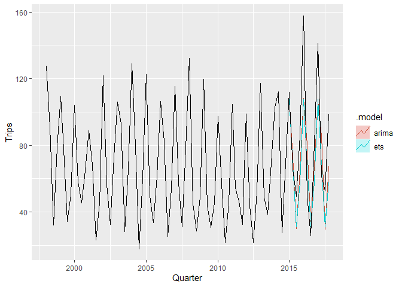

```r
forecast<- model %>% forecast(h = 12)

forecast %>%
  filter(Region == "East Coast",Purpose=="Holiday") %>%
  autoplot(df, level = NULL)
```

```r
East_Coast %>% select(arima) %>% report()
```

```
## Series: Trips
## Model: ARIMA(0,0,0)(2,1,0)[4]
##
## Coefficients:
##          sar1     sar2
##       -0.5962  -0.2491
## s.e.   0.1437   0.1431
##
## sigma^2 estimated as 264.2:  log likelihood=-269.03
## AIC=544.05   AICc=544.45   BIC=550.53
```

```r
East_Coast %>% select(ets) %>% report()
```

```
## Series: Trips
## Model: ETS(M,N,A)
##   Smoothing parameters:
##     alpha = 0.0001005895
##     gamma = 0.0005870065
##
##   Initial states:
##         l        s1        s2       s3       s4
##  66.20245 -8.126848 -35.06414 1.962036 41.22895
##
##   sigma^2:  0.0562
##
##      AIC     AICc      BIC
## 656.5113 658.3779 672.0478
```

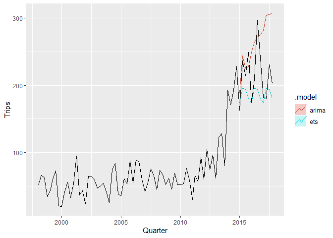

```r
forecast %>%
  filter(Region == "Australia's North West",Purpose=="Business") %>%
  autoplot(df, level = NULL)
```

```r
North_West %>% select(arima) %>% report()
```

```
## Series: Trips
## Model: ARIMA(2,1,1)(2,0,1)[4]
##
## Coefficients:
##           ar1      ar2     ma1    sar1    sar2     sma1
##       -1.5460  -0.6747  0.9440  0.5944  0.3282  -0.5199
## s.e.   0.1016   0.1003  0.0464  0.2396  0.2007   0.2594
##
## sigma^2 estimated as 524.3:  log likelihood=-303.79
## AIC=621.59   AICc=623.49   BIC=637.02
```

```r
North_West %>% select(ets) %>% report()
```

```
## Series: Trips
## Model: ETS(M,N,A)
##   Smoothing parameters:
##     alpha = 0.3592016
##     gamma = 0.0001154881
##
##   Initial states:
##        l      s1       s2      s3        s4
##  47.1953 -5.1762 7.558564 9.76347 -12.14583
##
##   sigma^2:  0.138
##
##      AIC     AICc      BIC
## 714.6264 716.4930 730.1629
```

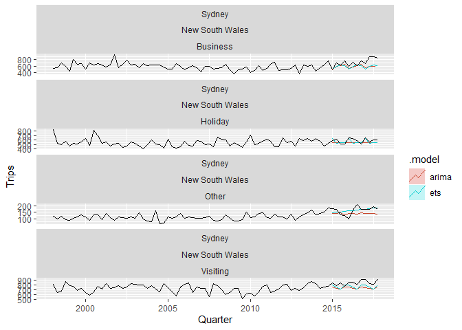

```r
forecast %>%
  filter(Region == "Sydney") %>%
  autoplot(df, level = NULL,)
```

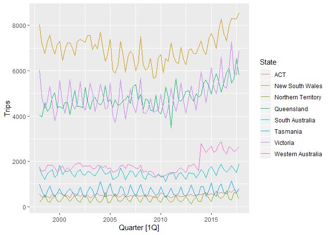

```r
States <- df %>%
  group_by(State) %>%
  summarise(Trips = sum(Trips))

States_train <- States %>%
  filter(year(Quarter)<= 2014)

States %>% autoplot(Trips)
```

```r
head(States,n=10)
```

```
## # A tsibble: 10 x 3 [1Q]
## # Key:       State [1]
##    State Quarter Trips
##    <chr>   <qtr> <dbl>
##  1 ACT   1998 Q1  551.
##  2 ACT   1998 Q2  416.
##  3 ACT   1998 Q3  436.
##  4 ACT   1998 Q4  450.
##  5 ACT   1999 Q1  379.
##  6 ACT   1999 Q2  558.
##  7 ACT   1999 Q3  449.
##  8 ACT   1999 Q4  595.
##  9 ACT   2000 Q1  600.
## 10 ACT   2000 Q2  557.
```

##### States data has the Trips knowledge that is done in each quarter on each states from year 1998 to 2017.

```r
States_model <- States_train %>%
  model(
    ets = ETS(Trips),
    arima = ARIMA(Trips)
  )
```

```r
States_model
```

```
## # A mable: 8 x 3
## # Key:     State [8]
##   State              ets          arima
##   <chr>              <model>      <model>
## 1 ACT                <ETS(A,N,N)> <ARIMA(0,0,0) w/ mean>
## 2 New South Wales    <ETS(A,N,A)> <ARIMA(0,0,3)(0,1,2)[4]>
## 3 Northern Territory <ETS(M,N,A)> <ARIMA(1,0,0)(2,1,0)[4]>
## 4 Queensland         <ETS(M,N,A)> <ARIMA(1,1,2)(2,0,0)[4]>
## 5 South Australia    <ETS(M,N,A)> <ARIMA(1,0,0)(0,1,1)[4]>
## 6 Tasmania           <ETS(M,N,M)> <ARIMA(0,0,1)(2,1,0)[4]>
## 7 Victoria           <ETS(M,N,M)> <ARIMA(0,0,3)(1,1,1)[4]>
## 8 Western Australia  <ETS(M,N,M)> <ARIMA(1,0,1) w/ mean>
```

```r
State_forecasts<-forecast(States_model,h = 12)
```

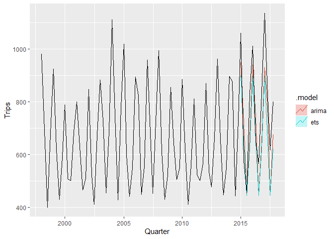

```r
State_forecasts %>%
  filter(State == "Tasmania") %>%
  autoplot(States, level = NULL)
```

```r
State_Tasmania<-States %>% filter(State == "Tasmania")
Tasmania_forecast<-State_forecasts %>%
  filter(State == "Tasmania")

accuracy(Tasmania_forecast,State_Tasmania)
```

```
## # A tibble: 2 x 10
##   .model State    .type    ME  RMSE   MAE   MPE  MAPE  MASE   ACF1
##   <chr>  <chr>    <chr> <dbl> <dbl> <dbl> <dbl> <dbl> <dbl>  <dbl>
## 1 arima  Tasmania Test   80.2  133.  119.  9.01  15.5  1.43 0.0843
## 2 ets    Tasmania Test  126.   157.  138. 14.9   17.1  1.66 0.241
```

##### Errors are:

- ME: Mean Error
- RMSE: Root Mean Squared Error
- MAE: Mean Absolute Error
- MPE: Mean Percentage Error
- MAPE: Mean Absolute Percentage Error
- MASE: Mean Absolute Scaled Error
- ACF1: Autocorrelation of errors at lag 1.

```r
Regions<-df %>%
  group_by(Region) %>%
  summarise(Trips = sum(Trips))

Region_train <- Regions %>%
  filter(year(Quarter)<= 2014)

Regions_model <- Region_train %>%
  model(
    ets = ETS(Trips),
    arima = ARIMA(Trips)
  )
Region_forecasts<-forecast(Regions_model,h = 12)
```

```r
head(Regions,n=10)
```

```
## # A tsibble: 10 x 3 [1Q]
## # Key:       Region [1]
##    Region   Quarter Trips
##    <chr>      <qtr> <dbl>
##  1 Adelaide 1998 Q1  659.
##  2 Adelaide 1998 Q2  450.
##  3 Adelaide 1998 Q3  593.
##  4 Adelaide 1998 Q4  524.
##  5 Adelaide 1999 Q1  548.
##  6 Adelaide 1999 Q2  569.
##  7 Adelaide 1999 Q3  538.
##  8 Adelaide 1999 Q4  562.
##  9 Adelaide 2000 Q1  646.
## 10 Adelaide 2000 Q2  563.
```

##### Regions data has the Trips knowledge that is done in each quarter on each regions from year 1998 to 2017.

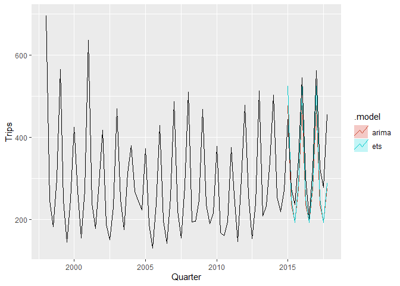

```r
Region_forecasts %>%
  filter(Region == "Peninsula") %>%
  autoplot(Regions, level = NULL)
```

```r
Regions_peninsula<-Regions %>% filter(Region == "Peninsula")
Peninsula_forecast<-Region_forecasts %>%
  filter(Region == "Peninsula")

accuracy(Peninsula_forecast,Regions_peninsula)
```

```
## # A tibble: 2 x 10
##   .model Region    .type    ME  RMSE   MAE   MPE  MAPE  MASE  ACF1
##   <chr>  <chr>     <chr> <dbl> <dbl> <dbl> <dbl> <dbl> <dbl> <dbl>
## 1 arima  Peninsula Test   61.7  78.7  67.1  17.3  18.5  1.34 0.222
## 2 ets    Peninsula Test   43.6  69.8  57.1  13.2  16.3  1.14 0.233
```

## REGRESSION MODELS

##### Since there are 5 different variables that effects the dependent variable,we can also use regression models for predictions on this data.

```r
df<-tourism
df$Years <- sapply(strsplit(as.character(df$Quarter), " "), "[", 1)
df$Quarters<-sapply(strsplit(as.character(df$Quarter)," "),"[",2)
data<-df[,-1]
data_new<-dummy.data.frame(data.frame(data), sep = "_")
```

##### Been generated dummy variables instead of the categorical variables.

```r
set.seed(1989)
trainIndex <- createDataPartition(data_new$Trips, p = .7,list = FALSE,times = 1)

train_data <- data_new[ trainIndex,]
test_data  <- data_new[-trainIndex,]


cat("Length of train data is",nrow(train_data))
```

```
## Length of train data is 17024
```

```r
cat("Length of test data is",nrow(test_data))
```

```
## Length of test data is 7296
```

```r
linear_reg <- lm(Trips ~. , data=train_data)
test<-select(test_data,-Trips)
test_results<-test_data$Trips
pred_linear <- predict(linear_reg, test)
summary(linear_reg)
```

```
##
## Call:
## lm(formula = Trips ~ ., data = train_data)
##
## Residuals:
##     Min      1Q  Median      3Q     Max
## -377.61  -29.11   -2.12   25.66  549.19
##
## Coefficients: (12 not defined because of singularities)
##                                           Estimate Std. Error t value
## (Intercept)                               69.60220    5.08436  13.689
## Region_Adelaide                          113.73505    6.18116  18.400
## `Region_Adelaide Hills`                  -24.19395    6.17531  -3.918
## `Region_Alice Springs`                   -17.34672    6.11899  -2.835
## `Region_Australia's Coral Coast`          16.74355    6.32440   2.647
## `Region_Australia's Golden Outback`       17.36538    6.19473   2.803
## `Region_Australia's North West`            7.67630    6.20853   1.236
## `Region_Australia's South West`          100.49076    6.30893  15.928
## Region_Ballarat                            3.44409    6.20846   0.555
## Region_Barkly                            -26.91066    6.20863  -4.334
## Region_Barossa                           -20.78138    6.32437  -3.286
## `Region_Bendigo Loddon`                   18.25948    6.14305   2.972
## `Region_Blue Mountains`                   16.15781    6.25750   2.582
## Region_Brisbane                          269.97315    6.29350  42.897
## Region_Bundaberg                           1.94733    6.16866   0.316
## Region_Canberra                           96.90917    6.20871  15.609
## `Region_Capital Country`                  29.19163    6.14309   4.752
## `Region_Central Coast`                    51.31716    6.10660   8.404
## `Region_Central Highlands`                -7.94543    6.27221  -1.267
## `Region_Central Murray`                   12.71290    6.19505   2.052
## `Region_Central NSW`                      86.93495    6.27951  13.844
## `Region_Central Queensland`               45.32107    6.24301   7.259
## `Region_Clare Valley`                    -22.50916    6.25022  -3.601
## `Region_Darling Downs`                    66.13909    6.22953  10.617
## Region_Darwin                              2.89490    6.12401   0.473
## `Region_East Coast`                      -10.37673    6.21560  -1.669
## `Region_Experience Perth`                156.48129    6.22898  25.122
## `Region_Eyre Peninsula`                   -9.01989    6.19552  -1.456
## `Region_Fleurieu Peninsula`                9.57304    6.14898   1.557
## `Region_Flinders Ranges and Outback`       0.03067    6.14344   0.005
```

[output cut: 188 more lines]

```
## Years_2013                               1.94e-08 ***
## Years_2014                               0.002884 **
## Years_2015                               0.019518 *
## Years_2016                               0.186437
## Years_2017                                     NA
## Quarters_Q1                              0.036135 *
## Quarters_Q2                              0.114904
## Quarters_Q3                              0.024849 *
## Quarters_Q4                                    NA
## ---
## Signif. codes:  0 '***' 0.001 '**' 0.01 '*' 0.05 '.' 0.1 ' ' 1
##
## Residual standard error: 65.01 on 16923 degrees of freedom
## Multiple R-squared:  0.7042, Adjusted R-squared:  0.7025
## F-statistic: 402.9 on 100 and 16923 DF,  p-value: < 2.2e-16
```

```r
pred_linear[pred_linear< 0]<-0
TMAE<-sum((data.frame(test_results)-(data.frame(pred_linear)))^2)
mean<-mean(test_results)
TMSE<-sum((data.frame(test_results)-mean)^2)
r_squared<-1-(TMAE/TMSE)
cat("R squared value for linear regression is",r_squared)
```

```
## R squared value for linear regression is 0.7172589
```

```r
error<-0
thebesterror<-10^10
the_best_mincut<-0
for (i in 1:50) {
  traintree<-tree(Trips~. ,data=data.frame(train_data),mincut=i)
  yhat = predict(traintree, newdata=data.frame(test))
  error<-(mean((yhat-test_results)^2))^0.5
  if(error<thebesterror){
    thebesterror<-error
    the_best<-error
    the_best_mincut<-i

  }
}
cat("The best mincut parameter is " ,the_best_mincut)
```

```
## The best mincut parameter is  1
```

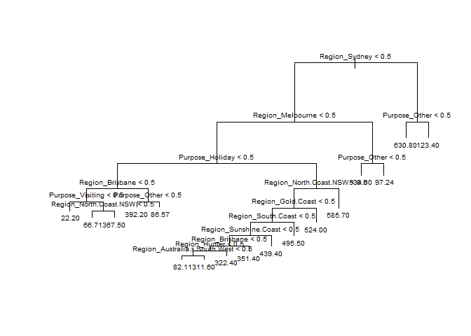

```r
traintree<-tree(Trips~. ,data=data.frame(train_data),mincut=1)
yhat_tree = predict(traintree, newdata=data.frame(test))
plot(traintree)
text(traintree,cex=0.6)
```

```r
TMAE<-sum((data.frame(test_results)-(data.frame(yhat_tree)))^2)
r_squared<-1-(TMAE/TMSE)
cat("R squared value for desicion tree is",r_squared)
```

```
## R squared value for desicion tree is 0.73862
```

```r
caret.control <- trainControl(method = "repeatedcv",number = 10,repeats = 10)

rpart.cv <- train(Trips~ .,data = data.frame(train_data),method = "rpart",
                  trControl = caret.control,tuneLength = 15)
```

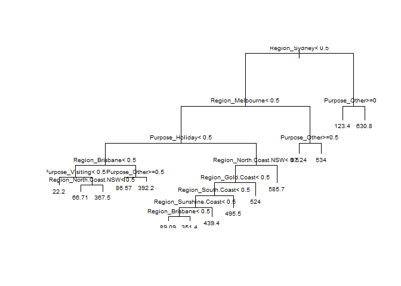

```r
rpart.best <- rpart.cv$finalModel
plot(rpart.best)
text(rpart.best,cex=0.6)
```

```r
yhat_rpart<-predict(rpart.best, newdata=data.frame(test))

TMAE<-sum((data.frame(test_results)-(data.frame(yhat_rpart)))^2)
r_squared<-1-(TMAE/TMSE)
cat("R squared value after cross validation is",r_squared)
```

```
## R squared value after cross validation is 0.7168508
```

```r
ensembled<-0.3*yhat_rpart+0.35*pred_linear+0.35*yhat_tree

TMAE<-sum((data.frame(test_results)-(data.frame(ensembled)))^2)
r_squared<-1-(TMAE/TMSE)
cat("R squared value after ensembling is",r_squared)
```

```
## R squared value after ensembling is 0.7917056
```

##### With ensembling method,higher r squared values can be obtained.